# Small Area Disease Risk Estimation and Visualization Using R

Paula Moraga

Centre for Health Informatics, Computing and Statistics (CHICAS), Lancaster Medical School

2018-06-07

Abstract

Small area disease risk estimation is essential for disease prevention and control. In this paper, we demonstrate how R can be used to obtain disease risk estimates and quantify risk factors using areal data. We explain how to define disease risk models and how to perform Bayesian inference using the *INLA* package. We also show how to make interactive maps of estimates using the *leaflet* package to better understand the disease spatial patterns and communicate the results. We show an example of lung cancer risk in Pennsylvania, United States, in year 2002, and demonstrate that R represents an excellent tool for disease surveillance by enabling reproducible health data analysis.

# Introduction

Disease risk mapping analyses can help to better understand the spatial variation of the disease, and allow the identification of important public health determinants. These analyses are essential to inform programmes of disease prevention and control. The increased availability of geospatial disease and population data has enabled to study a number of health outcomes worldwide such as influenza and cancer in developed countries (P. Moraga and Ozonoff 2013; P. Moraga and Kulldorff 2016), and neglected tropical diseases (P. Moraga et al. 2015; Hagan et al. 2016).

Areal disease data often arise when disease outcomes observed at point level locations are aggregated over subareas of the study region due to several reasons such as patient confidentiality. Producing disease risk estimates at areal level is complicated by the fact that raw rates can be very unstable in areas with small populations and for rare diseases, and also by the presence of spatial correlation that may exist due to spatially correlated risk factors (Leroux, Lei, and Breslow 2000). Thus, generalized linear mixed models are often used to obtain disease risk estimates since they enable to improve local estimates by accommodating spatial correlation and the effects of explanatory variables. Bayesian inference in these models may be performed using the Integrated Nested Laplace Approximation (INLA) approach (HRue, Martino, and Chopin 2009) which is a computational alternative to MCMC that allows to do approximate Bayesian inference in latent Gaussian models. This approach is implemented in the R package called *INLA* (Rue et al. 2017) (http://www.r-inla.org/).

Small area disease estimates can be visualized through maps, greatly facilitating effective communication. R provides excellent tools for visualization including packages for making interactive maps such as [*leaflet*](https://CRAN.R-project.org/package=leaflet) (Cheng, Karambelkar, and Xie 2017). The maps created with *leaflet* support interactive panning and zooming which is very convenient to examine small areas in detail.

# Disease risk models

Disease risk estimates in areas can be obtained by computing the Standardized Incidence Ratios (SIRs). For area $i$, $i=1,\ldots,n$, the SIR is obtained as the ratio of the observed to the expected disease counts: $SIR_i=Y_i/E_i$. The expected counts represent the total number of disease cases that one would expect if the population of the specific area behaved the way the standard (or regional) population behaves. The expected counts can be calculated using indirect standardization as
$$E_i=\sum_{j=1}^m r_j^{(s)} n_j,$$
where $r_j^{(s)}$ is the disease rate in stratum $j$ of the standard population, and $n_j$ is the population in stratum $j$ of the specific area. The SIR corresponding to area $i$, $SIR_i$, indicates whether the area $i$ has more ($SIR_i > 1$), equal ($SIR_i = 1$) or fewer ($SIR_i < 1$) cases observed than expected from the standard population. When applied to mortality data, the ratio is commonly known as the Standardized Mortality Ratio or SMR.

Although in some situations SIRs can give a sense of the disease’s spatial variability, very extreme values can occur in areas with small populations owing to the small sample sizes involved. In contrast, disease models are preferred to obtain disease risks estimates because they enable to incorporate covariates and borrow information from neighboring areas to improve local estimates, resulting in the smoothing or shrinking of extreme values based on small sample sizes (Gelfand et al. 2000). A common approach is to model the observed counts $Y_i$, $i=1,\ldots,n$, using a Poisson distribution with mean $E_i \times \theta_i$, where $E_i$ is the expected counts and $\theta_i$ is the relative risk in area $i$. Then, the log risks are modeled with a sum of an intercept to model the overall disease risk level, and random effects that account for extra-Poisson variability in the observed data (Lawson 2009). Areas with relative risks $\theta > 1$ and $\theta < 1$ are areas with high and low risks, respectively. Areas with $\theta = 1$ have the same risk as expected from the standard population.

The general model in disease mapping is expressed as
$$Y_i \sim Po(E_i \times \theta_i),\
i=1,\ldots,n,$$

$$\log(\theta_i)= \alpha + u_i +
v_i.$$
Here, $\alpha$ denotes the overall risk level, $u_i$ is a spatial structured random effect that models the spatial dependence between the relative risks, and $v_i$ is an unstructured exchangeable random effect that models uncorrelated noise. Often, other covariates or random effects are also included to quantify risk factors and deal with other sources of variability.

A model commonly used in disease mapping is the Besag-York-Mollié (BYM) model (Besag, York, and Mollié 1991). In this model, the spatially structured component $u_i$ is modelled with the conditional autoregressive (CAR) distribution which smoothes the data according to a certain adjacency structure given by a neighborhood matrix that specifies two areas are neighbours if they have a common boundary. The CAR distribution is expressed as
$$u_i|
\mathbf{u_{-i}} \sim N\left(\bar u_{\delta_i},
\frac{\sigma^2_u}{n_{\delta_i}}\right),$$
where $\bar u_{\delta_i}= n_{\delta_i}^{-1} \sum_{j \in \delta_i} u_j$, and $\delta_i$ and $n_{\delta_i}$ represent, respectively, the set of neighbours and the number of neighbours of area $i$. The unstructured component $v_i$ is modelled using independent and identically distributed normal variables with zero-mean and variance equal to $\sigma_v^2$.

# INLA

Traditionally, Bayesian inference has been implemented via MCMC methods which make inference tractable for complex models but may present convergence and computation time problems. Integrated Nested Laplace Approximation (INLA) is a computational less-intensive alternative to MCMC designed to perform approximate Bayesian inference in latent Gaussian models (HRue, Martino, and Chopin 2009). These models include a very wide and flexible class of models ranging from generalized linear mixed to spatial and spatio-temporal models. Specifically, models are of the form
$$y_i|\mathbf{x}, \boldsymbol{\theta} \sim
\pi(y_i|x_i, \boldsymbol{\theta}),$$

$$\mathbf{x}|\boldsymbol{\theta} \sim
N(\mathbf{0}, \boldsymbol{Q(\theta)}^{-1}),$$

$$\boldsymbol{\theta} \sim
\pi(\boldsymbol{\theta}),$$
where $\mathbf{y}$ are the observed data, $\mathbf{x}$ represents a Gaussian field, and $\boldsymbol{\theta}$ are hyperparameters. Observations $y_i$ are assumed to belong to an exponential family with mean $\mu_i = g^{-1}(\eta_i)$. The linear predictor $\eta_i$ accounts for effects of various covariates in an additive way,
$$\eta_i = \alpha + \sum_{k=1}^{n_{\beta}} \beta_k
z_{ki} + \sum_{j=1}^{n_f} f^{(j)}(u_{ji}).$$
Here, $\alpha$ is the intercept, $\{ \beta_k \}$’s quantify the linear effects of covariates $\{ z_{ki} \}$ on the response, and $\{ f^{(j)}(\cdot) \}$’s are a set of non-linear or smooth functions defined in terms of some covariates $\{ u_{ji}\}$. This formulation permits to accommodate a wide range of models thanks to the very different forms that the functions $\{f^{(j)}\}$ can take including the disease risk models previously introduced. INLA uses a combination of analytical approximation and numerical integration to obtain approximated posterior distributions of the parameters that can then be post-processed to compute quantities of interest like posterior expectations and quantiles.

The INLA approach is implemented in the R package *INLA*. This package is not on CRAN because it uses some external C libraries that make difficult to build the binaries. Therefore, when we install the package we need to use `install.packages()` adding the URL of the *INLA* repository:

```r
install.packages("INLA", repos = "https://inla.r-inla-download.org/R/stable",
                 dep = TRUE)
```

To fit a model using *INLA* we need to take two steps. First, we need to write the linear predictor of the model as a formula object in R. Then, we run the model calling the `inla()` function where we specify the formula, the family, the data and other options. Results can be inspected with the `summary()` function and the posterior distributions can be post-processed using a set of specific functions provided by *INLA*. Further details about how to use all these functions will be given in the disease mapping example in next Section.

# Example: lung cancer risk in Pennsylvania

In this Section we present an example of small area disease mapping study where we estimate the risk of lung cancer in Pennsylvania counties in year 2002. We use the data contained in the R package [*SpatialEpi*](https://CRAN.R-project.org/package=SpatialEpi) (Kim and Wakefield 2016). The data contain the counties population which was obtained from the 2000 decennial census, and the lung cancer and smoking proportions which were obtained from the Pennsylvania Department of Health. We show how to calculate the observed and expected disease cases, and the the SIRs in each of the counties. We also obtain disease risk estimates and quantify risk factors by fitting a Bayesian model using *INLA*. Finally, we show how to make interactive maps of the risk estimates using *leaflet*.

## Data

We start by loading the *SpatialEpi* package and attaching the `pennLC` data.

```r
library(SpatialEpi)
data(pennLC)
```

By typing `?pennLC` we see `pennLC` is a list with the following elements:

- `geo`: a data frame of county ids, and longitude and latitude of the geographic centroid of each county,
- `data`: a data frame of county ids, number of cases, population and strata information,
- `smoking`: a data frame of county ids and proportion of smokers,
- `spatial.polygon`: a `SpatialPolygons` object with the map of Pennsylvania.

`pennLC$data` contains the number of lung cancer cases and the population at county level, stratified on race (white and non-white), gender (female and male) and age group (under 40, 40-59, 60-69 and 70+).

We now create a data frame called `d` with columns containing the counties ids, the observed and expected number of cases, the smoking proportions and the SIRs. Specifically, `d` will contain the following columns:

- `id`: id of each county,
- `Y`: observed number of cases in each county,
- `E`: expected number of cases in each county,
- `smoking`: smoking proportion in each county,
- `SIR`: SIR of each county.

### Observed cases

`pennLC$data` contains the cases in each county stratified by race, gender and age. We can obtain the number of cases in each county, `Y`, by aggregating the rows of `pennLC$data` by county and adding up the observed number of cases.

```r
d <- aggregate(x = pennLC$data$cases, by = list(county = pennLC$data$county),
               FUN = sum)
```

`aggregate()` returns a data frame where the first row is the county and the second column is the observed number of cases in each of the counties. We set the column names of the returned object equal to `id` and `Y`.

```r
names(d) <- c("id", "Y")
```

### Expected cases

Now we calculate the indirectly standardized expected number of cases in each county as explained in Section 2. That is, we use the strata-specific rates from the the Pennsylvania population (standard population), and apply them to the population distribution of the county. The expected counts represent the total number of disease cases one would expect if the population in the county behaved the way the Pennsylvania population behaves. We can do this by using the `expected()` function of *SpatialEpi*. This function has three arguments, namely,

- `population`: a vector of population counts for each strata in each area,
- `cases`: a vector with the number of cases for each strata in each area,
- `n.strata`: number of strata considered.

Vectors `population` and `cases` have to be sorted by area first and then, within each area, the counts for all strata need to be listed in the same order. All strata need to be included in the vectors, including strata with 0 cases. Hence, to get the expected counts we first sort the data using the `order()` function where we specify the order as county, race, gender and finally age.

```r
pennLC$data <- pennLC$data[order(pennLC$data$county, pennLC$data$race,
                                 pennLC$data$gender, pennLC$data$age), ]
```

Then we call the `expected()` function to obtain the expected counts `E` in each county. In the function we set `population` equal to `pennLC$data$population` and `cases` equal to `pennLC$data$cases`. There are 2 races, 2 genders and 4 age groups for each county, so number of strata is set to 2 x 2 x 4 = 16.

```r
population <- pennLC$data$population
cases <- pennLC$data$cases
n.strata <- 16
E <- expected(population, cases, n.strata)
```

Now we add the vector `E` to the data frame `d` which contains the counties ids (`id`) and the observed counts (`Y`), making sure the `E` elements correspond to the counties in `d$id` in the same order. To do that, we use `match()` to calculate the vector of the positions that match `d$id` in `unique(pennLC$data$county)` which are the corresponding counties of `E`. Then we rearrange `E` using that vector.

```r
d$E <- E[match(d$id, unique(pennLC$data$county))]
```

### Smokers proportions

We also add to `d` the variable `smoking` which represents the proportion of smokers in each county. We add this variable using the `merge()` function where we specify the columns for merging as `id` in `d` and `county` in `pennLC$smoking`.

```r
d <- merge(d, pennLC$smoking, by.x = "id", by.y = "county")
```

### SIRs

Finally, we compute the vector of SIRs as the ratio of the observed to the expected counts, and add it to the data frame `d`.

```r
d$SIR <- d$Y/d$E
```

### Add data to map

The map of Pennsylvania counties is given by the `SpatialPolygons` object called `pennLC$spatial.polygon`. Using this object and the data frame `d` we can create a `SpatialPolygonsDataFrame` called `map`, that will allow us to make maps of the variables in `d`. In order to do that, we first set the row names of the data frame `d` equal to `d$id`. Then we merge `pennLC$spatial.polygon` and `d` matching the `SpatialPolygons` member Polygons ID slot values with the data frame row names.

```r
library(sp)
rownames(d) <- d$id
map <- SpatialPolygonsDataFrame(pennLC$spatial.polygon, d, match.ID = TRUE)
head(map@data)

##                  id    Y          E smoking       SIR
## adams         adams   55   69.62730   0.234 0.7899200
## allegheny allegheny 1275 1182.42804   0.245 1.0782897
## armstrong armstrong   49   67.61012   0.250 0.7247435
## beaver       beaver  172  172.55806   0.276 0.9967660
## bedford     bedford   37   44.19013   0.228 0.8372910
## berks         berks  308  300.70598   0.249 1.0242563
```

## Mapping variables

We can visualize the observed and expected disease counts, the SIRs, as well as the smokers proportions in an interactive chropleth map using the *leaflet* package. We create the map by first calling `leaflet()` and adding the default OpenStreetMap map tiles to the map with `addTiles()`. Then we add the Pennsylvania counties with `addPolygons()` where we specify the areas boundaries color (`color`) and the stroke width (`weight`). We fill the areas with the colours given by the color palette function generated with `colorNumeric()`, and set `fillOpacity` to a value less than 1 to be able to see the background map. We use `colorNumeric()` to create a color palette function that maps data values to colors according to a given palette. We create the function using the parameters `palette` with the color function that values will be mapped to, and `domain` with the possible values that can be mapped. Finally, we add the legend by specifying the color palette function (`pal`) and the values used to generate colors from the palette function (`values`). We set `opacity` to the same value as the opacity in the areas, and specify a title and a position for the legend.

```r
library(leaflet)
l <- leaflet(map) %>% addTiles()
pal <- colorNumeric(palette = "YlOrRd", domain = map$SIR)
l %>% addPolygons(color = "grey", weight = 1, fillColor = ~pal(SIR),
                  fillOpacity = 0.5) %>%
  addLegend(pal = pal, values = ~SIR, opacity = 0.5, title = "SIR",
            position = "bottomright")
```

We can improve the map by highlighting the counties when the mouse hovers over them, and showing information about the observed and expected counts, SIRs, and smoking proportions. We do this by adding the arguments `highlightOptions`, `label` and `labelOptions` to `addPolygons()`. We choose to highlight the areas using a bigger stroke width (`highlightOptions(weight = 4)`). We create the labels using HTML syntax. First, we create the text to be shown using the function `sprintf()` which returns a character vector containing a formatted combination of text and variable values and then applying `htmltools::HTML()` which marks the text as HTML. In `labelOptions` we specify the labels `style`, `textsize`, and `direction`. Possible values for `direction` are `left`, `right` and `auto` and this specifies the direction the label displays in relation to the marker. We choose `auto` so the optimal direction will be chosen depending on the position of the marker.

```r
labels <- sprintf("<strong> %s </strong> <br/> Observed: %s <br/> Expected: %s <br/>
                   Smokers proportion: %s <br/> SIR: %s",
                  map$id, map$Y, round(map$E, 2), map$smoking, round(map$SIR, 2)) %>%
  lapply(htmltools::HTML)

l %>% addPolygons(color = "grey", weight = 1, fillColor = ~pal(SIR), fillOpacity = 0.5,
                  highlightOptions = highlightOptions(weight = 4), label = labels,
                  labelOptions = labelOptions(style = list("font-weight" = "normal",
                                                           padding = "3px 8px"),
                                              textsize = "15px",
                                              direction = "auto")) %>%
  addLegend(pal = pal, values = ~SIR, opacity = 0.5, title = "SIR",
            position = "bottomright")
```

Figure 1 shows a snapshot of the interactive map created using `leaflet` showing the SIRs in the Pennsylvania counties. We can examine the map and see which counties have SIR equal to 1 indicating observed counts are the same as expected counts, and which counties have SIR greater (or smaller) than 1, indicating observed counts are greater (or smaller) than expected counts.

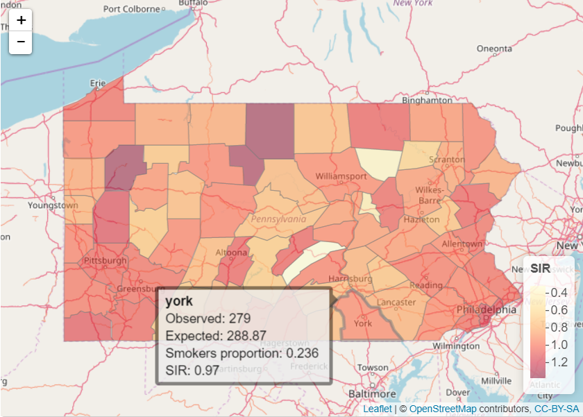

Figure 1: Snapshot of the interactive map created using `leaflet` showing the lung cancer SIRs in Pennsylvania counties in 2002.

This map gives a sense of the disease risk across Pennsylvania. However, SIRs are misleading and insufficiently reliable in counties with small populations. In contrast, model-based approaches enable to incorporate covariates and borrow information from neighboring counties to improve local estimates, resulting in the smoothing of extreme values based on small sample sizes. In the next section we will show how to obtain disease risk estimates using a Bayesian model using *INLA*.

## Modeling

In this Section we specify the model for the data, and detail the required steps to fit the model and obtain the disease risk estimates using *INLA*.

### Model

We specify a model assuming that the observed counts $Y_i$ are conditionally independently Poisson distributed,
$$Y_i|\theta_i \sim
Po(E_i \times \theta_i),\ i=1,\ldots,n,$$
where $E_i$ is the expected count and $\theta_i$ is the relative risk in area $i$. The logarithm of $\theta_i$ is expressed as follows:
$$\log(\theta_i) = \beta_0 + \beta_1 \times
smoking_i + u_i + v_i,$$
where $\beta_0$ is the intercept, $\beta_1$ is the coefficient of the smokers proportion covariate, $u_i$ is an structured spatial effect, $u_i|\mathbf{u_{-i}} \sim N(\bar{u}_{\delta_i}, \frac{\sigma_u^2}{n_{\delta_i}})$, and $v_i$ is an unstructured spatial effect, $v_i \sim N(0, \sigma_v^2)$.

### Neighbourhood matrix

We create the neighbourhood matrix needed to define the spatial random effect using the `poly2nb()` and the `nb2INLA()` functions of the [*spdep*](https://CRAN.R-project.org/package=spdep) package (Bivand 2017). First, we use `poly2nb()` to create a neighbours list based on areas with contiguous boundaries. Then, we use `nb2INLA()` to convert this list into a file with the representation of the neighbourhood matrix as required by *INLA* that is saved in the working directory. Then we read the file using the `inla.read.graph()` function of *INLA*, and store it in the object `g` which we will later use for specifying the spatial disease model with *INLA*.

```r
library(spdep)
library(INLA)
nb <- poly2nb(map)
head(nb)

## [[1]]
## [1] 21 28 67
##
## [[2]]
## [1]  3  4 10 63 65
##
## [[3]]
## [1]  2 10 16 32 33 65
##
## [[4]]
## [1]  2 10 37 63
##
## [[5]]
## [1]  7 11 29 31 56
##
## [[6]]
## [1] 15 36 38 39 46 54

nb2INLA("map.adj", nb)
g <- inla.read.graph(filename = "map.adj")
```

### Inference using INLA

As stated in Section 4.3.1, the model includes two random effects, namely, $u_i$ for modeling spatial residual variation, and $v_i$ for modeling unstructured noise. We need to include two vectors in the data that denote the indices of these random effects. We call `re_u` the vector denoting $u_i$, and `re_v` the vector denoting $v_i$. We set both `re_u` and `re_v` equal to $1,\ldots,n$, where $n$ is the number of counties. In our example, $n=67$ and this can be obtained with the number of rows in the data (`nrow(map@data)`).

```r
map$re_u <- 1:nrow(map@data)
map$re_v <- 1:nrow(map@data)
```

We specify the model formula by including the response in the left-hand side, and the fixed and random effects in the right-hand side. Random effects are set using `f()` with parameters equal to the name of the variable and the chosen model. For $u_i$, we use `model = "besag"` with neighbourhood matrix given by `g`. For $v_i$ we choose `model = "iid"`.

```r
formula <- Y ~ smoking + f(re_u, model = "besag", graph = g) + f(re_v, model = "iid")
```

We fit the model by calling the `inla()` function. We specify the formula, family, data, and the expected counts, and set `control.predictor` equal to `list(compute = TRUE)` to compute the posterior means of the linear predictors.

```r
res <- inla(formula, family = "poisson", data = map@data, E = E,
            control.predictor = list(compute = TRUE))
```

## Results

We can inspect the results object `res` using `summary()`.

```r
summary(res)

##
## Call:
## c("inla(formula = formula, family = \"poisson\", data = map@data, ",  "    E = E,
## control.predictor = list(compute = TRUE))")
##
## Time used:
##  Pre-processing    Running inla Post-processing           Total
##          0.3179          1.1198          0.2155          1.6531
##
## Fixed effects:
##                mean     sd 0.025quant 0.5quant 0.975quant    mode kld
## (Intercept) -0.3236 0.1503    -0.6212  -0.3234    -0.0279 -0.3231   0
## smoking      1.1567 0.6247    -0.0809   1.1582     2.3853  1.1619   0
##
## Random effects:
## Name   Model
##  re_u   Besags ICAR model
## re_v   IID model
##
## Model hyperparameters:
##                        mean       sd 0.025quant 0.5quant 0.975quant
## Precision for re_u    93.05    49.95      30.95    81.84     220.42
## Precision for re_v 17956.92 18118.49    1155.86 12549.06   65967.91
##                       mode
## Precision for re_u   63.63
## Precision for re_v 3103.11
##
## Expected number of effective parameters(std dev): 18.61(4.366)
## Number of equivalent replicates : 3.60
##
## Marginal log-Likelihood:  -320.53
## Posterior marginals for linear predictor and fitted values computed
```

We see the intercept $\hat \beta_0$= -0.3236 with a 95% credible interval equal to (-0.6212, -0.0279), and the coefficient of smoking is $\hat \beta_1=$ 1.1567 with a 95% credible interval equal to (-0.0810, 2.3853). This indicates that the smokers proportion has a positive although non significant effect on disease risk. We can plot the posterior distribution of the smoking coefficient. We do this by calculating a spline smoothing of the marginal distribution of the coefficient with `inla.smarginal()` and then plot it with `ggplot()` of [*ggplot2*](https://CRAN.R-project.org/package=ggplot2) package (Wickham and Chang 2016) (see Figure 2).

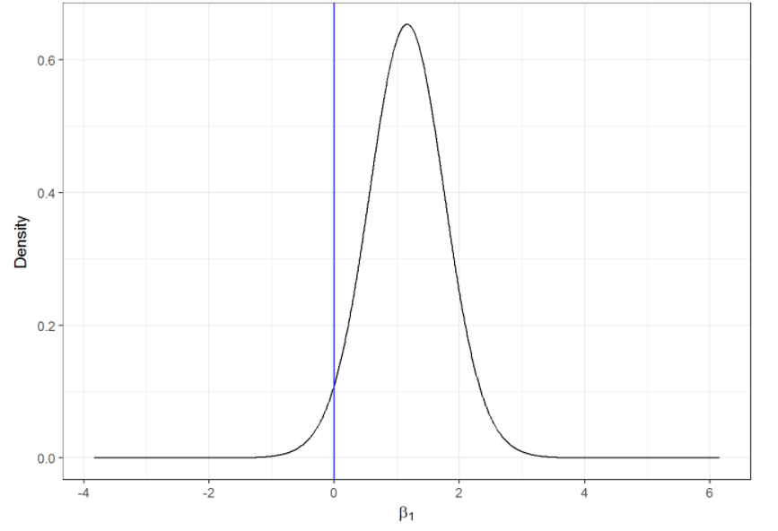

Figure 2: Posterior distribution of the coefficient of covariate smokers proportion.

```r
library(ggplot2)
marginal <- inla.smarginal(res$marginals.fixed$smoking)
marginal <- data.frame(marginal)
ggplot(marginal, aes(x = x, y = y)) + geom_line() +
  labs(x = expression(beta[1]), y = "Density") +
  geom_vline(xintercept = 0, col = "blue") + theme_bw()
```

The disease risk estimates and uncertainty for each of the counties are given by the mean posterior and the 95% credible intervals of $\theta_i$, $i=1,\ldots,n$ which are in the data frame `res$summary.fitted.values`. Here, column `mean` is the mean posterior and `0.025quant` and `0.975quant` are the 2.5 and 97.5 percentiles, respectively. We add these data to `map` to be able to make maps of these variables. We assign column `mean` to the estimate of the relative risk, and columns `0.025quant` and `0.975quant` to the lower and upper limits of 95% credible intervals of the risks.

```r
head(res$summary.fitted.values)

##                          mean         sd 0.025quant  0.5quant 0.975quant
## fitted.Predictor.01 0.8793912 0.05856462  0.7633052 0.8797123  0.9943822
## fitted.Predictor.02 1.0597516 0.02768817  1.0067707 1.0592960  1.1153106
## fitted.Predictor.03 0.9632142 0.05186119  0.8555748 0.9649813  1.0612639
## fitted.Predictor.04 1.0270184 0.05121187  0.9270286 1.0267054  1.1289998
## fitted.Predictor.05 0.9076782 0.05497745  0.7978867 0.9081541  1.0156557
## fitted.Predictor.06 0.9951907 0.04023105  0.9184425 0.9943119  1.0770673
##                          mode
## fitted.Predictor.01 0.8808707
## fitted.Predictor.02 1.0583769
## fitted.Predictor.03 0.9685918
## fitted.Predictor.04 1.0262831
## fitted.Predictor.05 0.9096874
## fitted.Predictor.06 0.9927333

map$RR <- res$summary.fitted.values[, "mean"]
map$LL <- res$summary.fitted.values[, "0.025quant"]
map$UL <- res$summary.fitted.values[, "0.975quant"]
```

## Mapping disease risk

We show the estimated disease risk in an interactive map using `leaflet`. In the map, we add labels that appear when mouse hovers over the counties showing information about observed and expected counts, SIRs, smokers proportions, RRs, and lower and upper limits of 95% credible intervals.

```r
pal <- colorNumeric(palette = "YlOrRd", domain = map$RR)

labels <- sprintf("<strong> %s </strong> <br/> Observed: %s <br/> Expected: %s <br/>
                  Smokers proportion: %s <br/> SIR: %s <br/> RR: %s (%s, %s)",
                  map$id, map$Y,  round(map$E, 2),  map$smoking, round(map$SIR, 2),
                  round(map$RR, 2), round(map$LL, 2), round(map$UL, 2)) %>%
  lapply(htmltools::HTML)

leaflet(map) %>% addTiles() %>%
  addPolygons(color = "grey", weight = 1, fillColor = ~pal(RR),  fillOpacity = 0.5,
              highlightOptions = highlightOptions(weight = 4), label = labels,
              labelOptions = labelOptions(style = list("font-weight" = "normal",
                                                       padding = "3px 8px"),
                                          textsize = "15px", direction = "auto")) %>%
  addLegend(pal = pal, values = ~RR, opacity = 0.5, title = "RR",
            position = "bottomright")
```

A snapshot of the interactive map created is shown in Figure 3. We observe counties with greater disease risk are located in the west and south east of Pennsylvania, and counties with lower risk are located in the center. The 95% credible intervals give a measure of the uncertainty in the risk estimates.

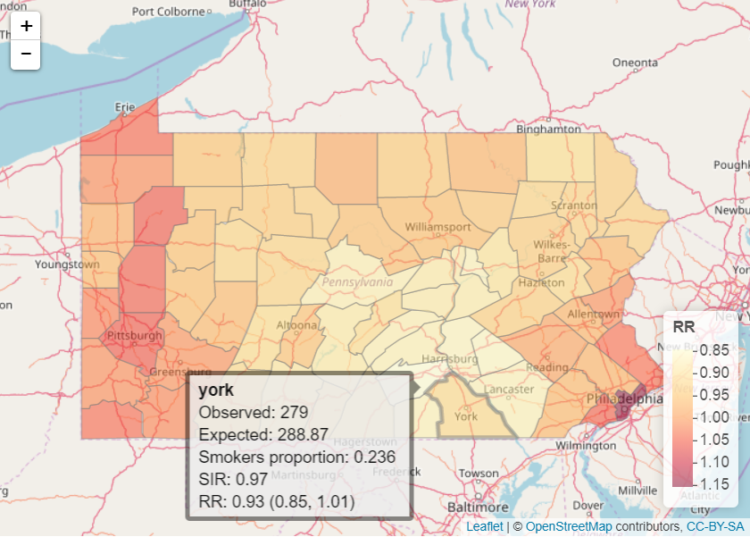

Figure 3: Snapshot of the interactive map created using `leaflet` showing the lung cancer RRs in Pennsylvania counties in 2002.

By typing `range(map@data$SIR)` and `range(map@data$RR)` we see that the range of SIRs is much wider about 1 compared to the range of RRs: (0.32 to 1.37) versus (0.85 to 1.15). We can also see the shrinkage of the RRs toward 1 by comparing maps of SIRs and RRs created using the same scale on the SIR gradient legend (see Figure 4). For example, in the SIRs map, in the central, less populated part of the state, there are 3 counties with extreme high values (dark colour) and 3 counties with extreme low values (light colour). In the RRs map, these extreme values shrink toward values closer to 1.

[figure not shown]

[figure not shown]

Figure 4: Snapshot of the interactive maps created using `leaflet` showing the lung cancer SIRs (left) and RRs (right) in Pennsylvania counties in 2002 using the same scale.

```r
pal <- colorNumeric(palette = "YlOrRd", domain = map$SIR)

leaflet(map) %>% addTiles() %>%
  addPolygons(color = "grey", weight = 1, fillColor = ~pal(RR),  fillOpacity = 0.5,
              highlightOptions = highlightOptions(weight = 4), label = labels,
              labelOptions = labelOptions(style = list("font-weight" = "normal",
                                                       padding = "3px 8px"),
                                          textsize = "15px", direction = "auto")) %>%
  addLegend(pal = pal, values = ~RR, opacity = 0.5, title = "RR",
            position = "bottomright")
```

# Summary

In this article we have shown how to obtain small area disease risk estimates, and generate interactive maps that help the understanding and interpretation of the results. First, we have introduced disease risk models using areal data, and have given an overview of the *INLA* package for performing Bayesian inference. Then, we have given a practical example where we have estimated lung cancer risk in Pennsylvania in 2002. We have conducted the analyses using several R packages such as *spdep* for spatial data manipulation, *SpatialEpi* for calculating the expected disease counts in the Pennsylvania counties, *INLA* for performing Bayesian inference, and *leaflet* and *ggplot2* for visualization of the results.

One limitation of disease models based on areal data is that they are often subject to ecological bias. This bias occurs when associations obtained from analyses that use variables at an aggregated level lead to conclusions different from analyses that use the same variables measured at an individual level (Robinson 1950). Therefore, whenever point data are available, it is preferable to use disease models without aggregating data and predict disease risk in a continuous surface (Paula Moraga et al. 2017; Diggle et al. 2013).

It is also possible to use R to build tools to better communicate the results to stakeholders and the general public. For instance, summaries and maps of disease risk estimates can be presented in interactive dashboards using [*flexdashboard*](https://CRAN.R-project.org/package=flexdashboard) (Allaire 2017), and web applications using [*shiny*](https://CRAN.R-project.org/package=shiny) (Chang et al. 2017). One example of such web application is the [*SpatialEpiApp*](https://CRAN.R-project.org/package=SpatialEpiApp) package (Paula Moraga 2017a, 2017b) which is useful for disease risk mapping and the detection of clusters. This is an easy to use application where users simply need to upload their data and click several buttons that execute the tasks and process the outputs, making spatial analysis methods accessible to multiple disciplines. *SpatialEpiApp* creates interactive visualizations by using the packages *leaflet* for rendering maps, [*dygraphs*](https://CRAN.R-project.org/package=dygraphs) (Vanderkam et al. 2017) for plotting time series, and [*DT*](https://CRAN.R-project.org/package=DT) (Xie 2016) for displaying data tables, and enables the generation of reports by using [*rmarkdown*](https://CRAN.R-project.org/package=rmarkdown) (Allaire et al. 2017). In conclusion, R represents an excellent tool for disease surveillance by enabling reproducible health data analysis.

Allaire, JJ. 2017. *Flexdashboard: R Markdown Format for Flexible Dashboards*. https://CRAN.R-project.org/package=flexdashboard.

Allaire, JJ, Yihui Xie, Jonathan McPherson, Javier Luraschi, Kevin Ushey, Aron Atkins, Hadley Wickham, Joe Cheng, and Winston Chang. 2017. *Rmarkdown: Dynamic Documents for r*. https://CRAN.R-project.org/package=rmarkdown.

Besag, J., J. York, and A. Mollié. 1991. “Bayesian Image Restoration with Applications in Spatial Statistics (with Discussion).” *Annals of the Institute of Statistical Mathematics* 43: 1–59. https://doi.org/10.1007/BF00116466.

Bivand, Roger. 2017. *Spdep: Spatial Dependence: Weighting Schemes, Statistics and Models*. https://CRAN.R-project.org/package=spdep.

Chang, Winston, Joe Cheng, JJ Allaire, Yihui Xie, and Jonathan McPherson. 2017. *Shiny: Web Application Framework for r*. https://CRAN.R-project.org/package=shiny.

Cheng, Joe, Bhaskar Karambelkar, and Yihui Xie. 2017. *Leaflet: Create Interactive Web Maps with the JavaScript ’Leaflet’ Library*. http://rstudio.github.io/leaflet/.

Diggle, P. J., P. Moraga, B. Rowlingson, and B. Taylor. 2013. “Spatial and Spatio-Temporal Log-Gaussian Cox Processes: Extending the Geostatistical Paradigm.” *Statistical Science* 28 (4): 542–63. https://doi.org/10.1214/13-STS441.

Gelfand, A. E., P. J. Diggle, M. Fuentes, and P. Guttorp. 2000. *Handbook of Spatial Statistics*. Boca Raton, Fl.: Chapman; Hall/CRC.

Hagan, J. E., P. Moraga, F. Costa, N. Capian, G. S. Ribeiro, E. A. Wunder Jr, R. D. Felzemburgh, et al. 2016. “Spatio-Temporal Determinants of Urban Leptospirosis Transmission: Four-Year Prospective Cohort Study of Slum Residents in Brazil.” *Public Library of Science: Neglected Tropical Diseases* 10 (1): e0004275. https://doi.org/10.1371/journal.pntd.0004275.

HRue, Sara Martino, and Nicholas Chopin. 2009. “Approximate Bayesian Inference for Latent Gaussian Models Using Integrated Nested Laplace Approximations (with Discussion).” *Journal of the Royal Statistical Society B* 71: 319–92. https://doi.org/10.1111/j.1467-9868.2008.00700.x.

Kim, Albert Y., and Jon Wakefield. 2016. *SpatialEpi: Methods and Data for Spatial Epidemiology*. https://CRAN.R-project.org/package=SpatialEpi.

Lawson, Andrew B. 2009. *Bayesian Disease Mapping: Hierarchical Modeling in Spatial Epidemiology*. Boca Raton, Fl.: Chapman; Hall/CRC.

Leroux, B. G., X. Lei, and N. Breslow. 2000. “Estimation of Disease Rates in Small Areas: A New Mixed Model for Spatial Dependence.” In *Statistical Models in Epidemiology, the Environment, and Clinical Trials*, edited by M. E. Halloran and D. Berry, 179–91. The IMA Volumes in Mathematics and Its Applications. New York, NY: Springer-Verlag.

Moraga, Paula. 2017a. *SpatialEpiApp: A Shiny Web Application for the Analysis of Spatial and Spatio-Temporal Disease Data*. https://CRAN.R-project.org/package=SpatialEpiApp.

———. 2017b. “SpatialEpiApp: A Shiny Web Application for the Analysis of Spatial and Spatio-Temporal Disease Data.” *Spatial and Spatio-Temporal Epidemiology* 23: 47–57. https://doi.org/10.1016/j.sste.2017.08.001.

Moraga, Paula, Susanna Cramb, Kerrie Mengersen, and Marcello Pagano. 2017. “A Geostatistical Model for Combined Analysis of Point-Level and Area-Level Data Using INLA and SPDE.” *Spatial Statistics* 21: 27–41. https://doi.org/10.1016/j.spasta.2017.04.006.

Moraga, P., J. Cano, R. F. Baggaley, J. O. Gyapong, S. Njenga, B. Nikolay, E. Davies, et al. 2015. “Modelling the Distribution and Transmission Intensity of Lymphatic Filariasis in Sub-Saharan Africa Prior to Scaling up Interventions: Integrated Use of Geostatistical and Mathematical Modelling.” *Public Library of Science: Neglected Tropical Diseases* 8: 560. https://doi.org/10.1186/s13071-015-1166-x.

Moraga, P., and M. Kulldorff. 2016. “Detection of Spatial Variations in Temporal Trends with a Quadratic Function.” *Statistical Methods for Medical Research* 25 (4): 1422–37. https://doi.org/10.1177/0962280213485312.

Moraga, P., and A. Ozonoff. 2013. “Model-Based Imputation of Missing Data from the 122 Cities Mortality Reporting System (122 CMRS).” *Stochastic Environmental Research and Risk Assessment* 29 (5): 1499–1507. https://doi.org/10.1007/s00477-014-0974-4.

Robinson, W. S. 1950. “Ecological Correlations and the Behavior of Individuals.” *American Sociological Review* 15 (3): 351–57. https://doi.org/10.2307/2087176.

Rue, Havard, Sara Martino, Finn Lindgren, Daniel Simpson, Andrea Riebler, Elias Teixeira Krainski, and Geir-Arne Fuglstad. 2017. *INLA: Functions Which Allow to Perform Full Bayesian Analysis of Latent Gaussian Models Using Integrated Nested Laplace Approximations*.

Vanderkam, Dan, JJ Allaire, Jonathan Owen, Daniel Gromer, Petr Shevtsov, and Benoit Thieurmel. 2017. *Dygraphs: Interface to ’Dygraphs’ Interactive Time Series Charting Library*. https://CRAN.R-project.org/package=dygraphs.

Wickham, Hadley, and Winston Chang. 2016. *Ggplot2: Create Elegant Data Visualisations Using the Grammar of Graphics*. https://CRAN.R-project.org/package=ggplot2.

Xie, Yihui. 2016. *DT: A Wrapper of the JavaScript Library ’DataTables’*. https://CRAN.R-project.org/package=DT.